# Differences in Cognition

.

📃 Phase 1: Proposal

- Introduction
- Domain understanding
- Data sourcing
- Analytical approach

📊 Phase 2: Data provisioning

- Data requirements
- Data collection
- Data preparation
- Data understanding

🤖 Phase 3: Predictions

- Preprocessing
- Modelling
- Evaluation

# Introduction

They have collected data on each participant’s performance during the test. This data consists of for example: their clicked selections, timing of each click, and time spent on each answer. The data also has results from participants’ CITO-score and Big-5 Personality test.

The aim here is to move beyond the traditional outcome measure of the test, which is the total number of correct answers completed in any given time frame. While this does give some insight, it has significant limitations in further analyzing and assessing one’s performance.

This is where our main objective grows from. We as a project group want to focus on what happens in a more nuanced form during the test itself. We want to identify patterns, such as the sequence of figures the participant chooses or maybe changes in speed, based on factors like figure relationships or errors made during the test.

These patterns can lead to new scoring metrics, and with that hopefully bring more insight to assist psychologists in better understanding the test-taker’s cognitive process.

Getting a better idea about this is important as it can uncover potential challenges a young individual might face and show where they may need more assistance (e.g, school).

Next to a better understanding, we also hope to bring new metrics that can bring in additional insight. For example, metrics that make it possible to analyze if there is a possible correlation between strategies used and certain personality traits of the young individual.

# Domain understanding

We’ve spoken already about a few things like the CITO score, Big-5 test, and the Five-Point test. You may already have an idea of what these things may be, but it’s important for people who are not sufficiently familiar with a certain domain, to further indulge themselves to be of better help by mutual understanding.

Understanding what you’re doing while you’re doing it provides better context for the work you’re putting out. Communication is improved between various parties, and it makes your output of better quality when you know enough to be able to see certain details.

### The CITO test

The CITO test is an official test given in The Netherlands, usually at the end of primary school. It is used to help teachers in determining how well students understand foundational courses, directing their academic path at high school, and providing additional information on how they may develop as learners.

The test assesses certain subjects like language, math, and methods of learning. There are multiple areas to this test, each focusing on a different area of expertise and knowledge. The questions are created to span a wide range of difficulty levels, ensuring an in-depth awareness of a student’s cognitive abilities.

The test has a multiple-choice structure. In order to ensure consistency and fairness for every test-taker, it is conducted under carefully monitored circumstances.

The final score is between 500 and 550. It is usually divided by 5 steps of 20%, where each step has a certain comparison to the country’s mean.

It’s important to note that the test score is not the definite decider in which direction the student goes starting high school, it is intended as a guideline for the teachers who should take all factors into consideration in their final assessment.

### The Five-Point test.

The Five-Point test is among other areas a problem-solving and creativity assessment that involves connecting five dots arranged like in the shape of the number 5 on a set of dice. The goal is to evaluate a participant’s ability to strategize, think critically, and show creative problem solving skills within a given time frame.

In this context, the participant is given 180 seconds to create as many unique figures or shapes as they can by connecting dots to create straight lines between the 2 points they’ve selected.

As was mentioned earlier, the goal is to use the test as a measure of problem-solving skills, strategic thinking, and creativity. It helps assess a participant’s ability to see patterns, think outside the box, and create multiple solutions whilst under time pressure.

### The Big-Five Personality test.

The Big-Five Personality test, also known as the Five-Factor Model is one of the few psychological frameworks that are used by various doctors, researchers among some examples. It is widely considered the most scientifically validated. It looks into five major dimensions, hence its name.

Openness looks at creativity, a willingness to explore and chase after new ideas. If you score high; you are often more likely to be curious, imaginative and open to the idea of change.

Conscientiousness looks at organization, responsibility and reliability in your behaviour. If you score high here you are more likely to be organized and diligent in your pursuits in all kinds of areas.

Extraversion looks at how outgoing, sociable, and energized you are by social interactions. If you score high you are more likely to thrive in social settings, enjoy the company of others and often naturally take on leadership roles.

Agreeableness looks at your level of “warmth”, cooperation, and compassion. If you score high on Agreeableness you tend to be more considerate, empathetic, and cooperative.

The final trait Neuroticism looks at your emotional stability and resilience to stress. If you score high on Neuroticism you are more likely to experience heightened emotional reactivity and could possibly be more prone to anxiety and mood swings.

It can be a valuable tool for a more nuanced comprehension of individuals’ differences.

# Data sourcing

Data Characteristics:

- Student ID: This is likely a unique identifier for each student, allowing for individual tracking and analysis.
- Pattern: This could refer to the usage pattern or behavior of the students interacting with the data.
- Time Stamp per Figure: Indicates when each figure was presented or interacted with, providing a temporal dimension to the data.
- Click Statuses:Describes the state of each click, helping to understand whether a student interacted with a figure or not.
- Order of Clicks: The sequence in which the clicks occurred, offering insights into navigation and interaction flow.
- Timestamp of Each Click: Provides detailed timing information for each click, aiding in time-based analysis.

Selection of Data Source: The data set provided by the company suggests a collaborative effort or partnership between the student and the company. The inclusion of student-specific data indicates a focus on individual behavior, which could be valuable for personalized insights.

Data Diversity: The inclusion of various data elements (Student ID, pattern, time stamps, click statuses, order of clicks) suggests a diverse dataset capturing multiple facets of student interaction. The diversity in data types (categorical, temporal) allows for a comprehensive analysis of student behavior.

Legal and Ethical Compliance:

- Privacy Concerns: Since the data involves student information, privacy and confidentiality are paramount. Ensure that the data is anonymized or pseudonymized to protect individual identities.
- Consent: It's crucial to confirm that the students have given informed consent for the use of their data in this context.
- Compliance with Regulations: Adherence to data protection regulations (such as GDPR, HIPAA, or other applicable laws) should be ensured to avoid legal issues.
- Transparent Use: The students should be aware of the purpose for which their data is being used and should have the option to opt out if possible.

# Analytical Approach

Target Variable We want to predict patterns based on analyzing participants’ clicks and other features in the dataset like the sequence of their clicked points.

Five Points Test(FPT) Dataset: Target Variable: FPT Score The FPT score represents an individual’s ability to generate unique designs within a set time limit. It’s a measure of cognitive functioning and creativity. Cito score dataset: target variable: score between 500 and 550 The cito test is a test children take in eighth grade. They are questioned about different subjects and their score determines which level of high school they go in. Big five dataset: Target Variable:Openness, Conscientiousness, Extraversion, Agreeableness, Emotional Stability These personality traits are the outcomes of interest, and we might want to analyze how they relate to FPT score or other variables.

Nature of the problem FPT Dataset: Nature of the Problem: Regression Analysis We will perform regression analysis to predict FPT scores or understand the factors influencing FPT performance. Cito Dataset: Nature of the Problem: Regression Analysis we are going to predict cito score based on the five point test results Big five Dataset: We should explore first the relationships between personality traits and other variables using EDA and correlation analysis.

# Data Requirements

# Data Collection

We received 3 csv files from the professors of the University of maastricht.

Below we'll explain each dataset and what it contains.

- Five Points Test(FPT) Dataset: This dataset contains an identifier followed wich a couple values for each picture. these values are pattern, timestamp, timestampsm, statuscl, number and timestampel these values are all in a single column.
- Cito score dataset: The dataset contains records of students' performance on a standardized test. Each record includes an identifier for the student, the school year, a standard score representing their overall performance, and details about their performance on specific sections of the test.
- Big five dataset: The dataset contains responses to a personality test based on the Big Five personality traits model. It includes scores for openness, conscientiousness, extraversion, agreeableness, and neuroticism. Each row represents an individual's scores across these traits, likely derived from their answers to a series of questions.

# Data Preparation

Because the csv file for the five points dataset is very untidy, and not ready to put in a machine learning model, we will tidy and prepare the data for better workability.

```python
import pandas as pd
import seaborn as sns
import matplotlib.pyplot as plt
from datetime import datetime, timedelta
from ast import literal_eval
import numpy as np

df = pd.read_csv('fivepoint_test.csv', sep=";", parse_dates=['timestamp'])
df.head(6)
```

|  | primary | idll_vo3lv | name | value | timestamp |
| --- | --- | --- | --- | --- | --- |
| 0 | 36 | 1 | patternsm | 0,0,1,0,0,0,1,0 | 2020-03-09 09:32:32 |
| 1 | 37 | 1 | timestampsm | 2520 | 2020-03-09 09:32:32 |
| 2 | 38 | 1 | statuscl | 1,1 | 2020-03-09 09:32:32 |
| 3 | 39 | 1 | numbercl | 3,7 | 2020-03-09 09:32:32 |
| 4 | 40 | 1 | timestampcl | 1583742751461,1583742751869 | 2020-03-09 09:32:32 |
| 5 | 41 | 1 | timestampload | 1583742749790 | 2020-03-09 09:32:32 |

### Fixing the row ordering issue

In a normal case, the order of rows with the certain variables will be:

1. patternsm
2. timestampsm
3. statuscl
4. numbercl
5. timestampcl
6. timestampload

But, sometimes in the dataset, the ordering will be duplicated which has nothing to do with each other, so it will appear like:

1. patternsm
2. patternsm
3. timestampsm
4. timestampsm
5. statuscl
6. statuscl
7. numbercl
8. numbercl
9. timestampcl
10. timestampcl
11. timestampload
12. timestampload

The following code will fix that

What this does, is that it looks through each row with a predefined order as we have mentioned above. If the order is obstructed it will put the first "faulty" item in a stack. Because of the way (and luck) that the dataset either has a perfect order or one that is duplicated, we don't have to account for any other factors except those 2 combinations.

it will then look in the list of stack items and put those in the correct order so the whole dataset has the same order.

```python
df.reset_index()

order = ["patternsm", "timestampsm", "statuscl", "numbercl", "timestampcl", "timestampload"]
order_i = 0

stack = []
output = []

for i, row in df.iterrows():
    print("running:", i, "   ", end="\r")
    for stack_item in stack:
        if(stack_item["name"] == order[order_i]):
            output.append(stack_item)
            order_i += 1
            if(order_i >= len(order)): order_i = 0
        else:
            break

    if(row["name"] == order[order_i]):
        output.append(row)
        order_i += 1
        if(order_i >= len(order)): order_i = 0
    else:
        stack.insert(0, row)
```

```
running: 1122113    24062     410342               743651    824768    911536
```

### Checking to see if any errors were made

This will look at if anywhere in the dataset the order is not the same, it will then stop the process and print out an error

```python
order = ["patternsm", "timestampsm", "statuscl", "numbercl", "timestampcl", "timestampload"]
order_i = 0
for item in output:
    if(item['name'] != order[order_i]):
        print("ERROR")
        break
    order_i += 1
    if(order_i >= len(order)): order_i = 0
```

No errors, so that means everything is ordered correctly

### Widening the dataset

Now, instead of having "columns" in cells, we will extract the features, put them in separate columns and retrieve their value under it.

This will make every 1 row, 1 figure made in during the test for any given student.

This will allow us to have a better workable dataset which will make modeling and other uses (like EDA) better doable

```python
counter = -1
current_pattern = 0
final_out = []

for item in output:
    counter += 1
    if(counter % 6 == 0):
        print(counter, "    ", end="\r")
        final_out.append(current_pattern)
        current_pattern = item
        current_pattern['patternsm'] = item['value']
    if(counter % 6 == 1):
        current_pattern['timestampsm'] = item['value']
    if(counter % 6 == 2):
        current_pattern['statuscl'] = item['value']
    if(counter % 6 == 3):
        current_pattern['numbercl'] = item['value']
    if(counter % 6 == 4):
        current_pattern['timestampcl'] = item['value']
    if(counter % 6 == 5):
        current_pattern['timestampload'] = item['value']

final_out.remove(0)

print("done")
print("converting to DataFrame")
data = pd.DataFrame(final_out)
print("done")
```

```
done040
converting to DataFrame
done
```

So now that it put into a new dataframe, we can check the results and see what happened.

Before that, we drop the old 2 columns called name and value which originally had one of the 6 features in them and its corresponding value

```python
data = data.drop(['name', 'value'], axis=1)
data.head(5)
```

|  | primary | idll_vo3lv | timestamp | patternsm | timestampsm | statuscl | numbercl | timestampcl | timestampload |
| --- | --- | --- | --- | --- | --- | --- | --- | --- | --- |
| 0 | 36 | 1 | 2020-03-09 09:32:32 | 0,0,1,0,0,0,1,0 | 2520 | 1,1 | 3,7 | 1583742751461,1583742751869 | 1583742749790 |
| 6 | 47 | 1 | 2020-03-09 09:32:35 | 1,1,0,0,0,0,0,0 | 2576 | 1,1 | 2,1 | 1583742753766,1583742754238 | 1583742752391 |
| 12 | 53 | 1 | 2020-03-09 09:32:37 | 0,0,1,1,0,0,0,0 | 2541 | 1,1 | 3,4 | 1583742756412,1583742756876 | 1583742755058 |
| 18 | 59 | 1 | 2020-03-09 09:32:40 | 0,0,0,0,0,1,0,1 | 2540 | 1,1 | 8,6 | 1583742759029,1583742759476 | 1583742757674 |
| 24 | 65 | 1 | 2020-03-09 09:32:42 | 0,0,1,1,0,0,0,0 | 2384 | 1,1 | 4,3 | 1583742761381,1583742762222 | 1583742760309 |

As you can see, each feature has its own column with its corresponding value attached to it, with each row being 1 complete figure in the test

### Exporting the modified dataframe into a new csv file

This simply puts the dataframe into a csv file so we can keep the original data intact may we ever need it

```python
data.to_csv('fivepoint_test_processed.csv')
```

# Data understanding

To begin understanding the data, we will do some basic aggregation and we will extract time periods of a test that was taken.

We make 18 time window blocks of 10 seconds each, the test is 180 seconds long so that divides the windows perfectly.

```python
# Helper functions
def convert_to_list(s):
    try:
        return literal_eval(f'[{s}]') if s else []
    except (ValueError, SyntaxError):
        return []

def format_time(seconds):
    if np.isnan(seconds) or seconds < 60:
        return f"{seconds:.2f} sec"
    else:
        minutes = int(seconds // 60)
        seconds = seconds % 60
        return f"{minutes} min {seconds:.2f} sec"

# Constants
MAX_GAP = 300  # 5 minutes in seconds
BLOCK_DURATION = 10  # Block duration in seconds
TOTAL_BLOCKS = 18  # Total number of blocks

# Load the dataset
file_path = 'fivepoint_test_processed.csv'
df = pd.read_csv(file_path, delimiter=',', header=0)

# Process each student's data
student_data_list = []
for student_id, student_group in df.groupby('idll_vo3lv'):
    # Extract and process timestamps and patterns for the student
    student_timestamps = student_group['timestampcl']
    student_patterns = student_group['patternsm']

    # Flatten the lists and sort timestamps
    timestamps = sorted([ts for sublist in student_timestamps.apply(convert_to_list) for ts in sublist])
    patterns = [pattern for sublist in student_patterns.apply(convert_to_list) for pattern in sublist]

    # Convert timestamps to datetime objects
    timestamps = [datetime.fromtimestamp(ts / 1000) for ts in timestamps]

    # Initialize blocks with both clicks and unique patterns
    if timestamps:
        start_time = timestamps[0]
        blocks = [{'start': start_time + timedelta(seconds=i * BLOCK_DURATION),
                   'end': start_time + timedelta(seconds=(i + 1) * BLOCK_DURATION),
                   'clicks': 0,
                   'unique_patterns': set()} for i in range(TOTAL_BLOCKS)]

        # Process timestamps and patterns
        for ts, pattern in zip(timestamps, patterns):
            pattern_key = tuple([pattern]) if isinstance(pattern, int) else tuple(pattern)
            for block in blocks:
                if block['start'] <= ts < block['end']:
                    block['clicks'] += 1
                    block['unique_patterns'].add(pattern_key)

        # Calculate total duration and average time between clicks
        valid_time_diffs = [((timestamps[i] - timestamps[i-1]).total_seconds()) for i in range(1, len(timestamps))
                            if (timestamps[i] - timestamps[i-1]).total_seconds() <= MAX_GAP]
        test_duration = (timestamps[-1] - timestamps[0]).total_seconds()
        average_time_between_clicks = np.mean(valid_time_diffs) if valid_time_diffs else 0

        # Prepare student data with block information
        student_data = {
            'Student_ID': student_id,
            'Total_Clicks': len(timestamps),
            'Total_Unique_Figures': len(set(pattern_key for pattern_key in patterns)),
            'Average_Time_Between_Clicks': format_time(average_time_between_clicks),
            'Test_Duration': format_time(test_duration)
        }
        # Add block-wise clicks and unique pattern counts to the student data
        for i, block in enumerate(blocks, 1):
            student_data[f'Block_{i}_Clicks'] = block['clicks']
            student_data[f'Block_{i}_Unique_Patterns'] = len(block['unique_patterns'])

        student_data_list.append(student_data)

# Create the DataFrame with the aggregated data
analysis_df = pd.DataFrame(student_data_list)

# Display the DataFrame
print(analysis_df.head(10))
```

```
   Student_ID  Total_Clicks  Total_Unique_Figures Average_Time_Between_Clicks  \
0           1            11                     2                    1.20 sec
1           2            96                     2                    2.16 sec
2           3           154                     2                    1.23 sec
3           4           183                     2                    1.09 sec
4           5           170                     2                    1.16 sec
5           6           126                     2                    1.57 sec
6           7           100                     2                    1.88 sec
7           8            95                     2                    1.90 sec
8           9           107                     2                    1.80 sec
9          10           155                     2                    1.24 sec

      Test_Duration  Block_1_Clicks  Block_1_Unique_Patterns  Block_2_Clicks  \
0  88 min 41.87 sec               9                        2               1
1   3 min 25.04 sec               9                        1               4
```

[output cut: 58 more lines]

### Plotting the time window blocks together with number of clicks during each block and the amount of unique figures made

With this, we hope to expect to find out if there for example is a possible correlation between the number of clicks made during a time window and the amount of unique figures. The assumption here is that more clicks would technically equal more unique figures because there are more possibilities with more actions.

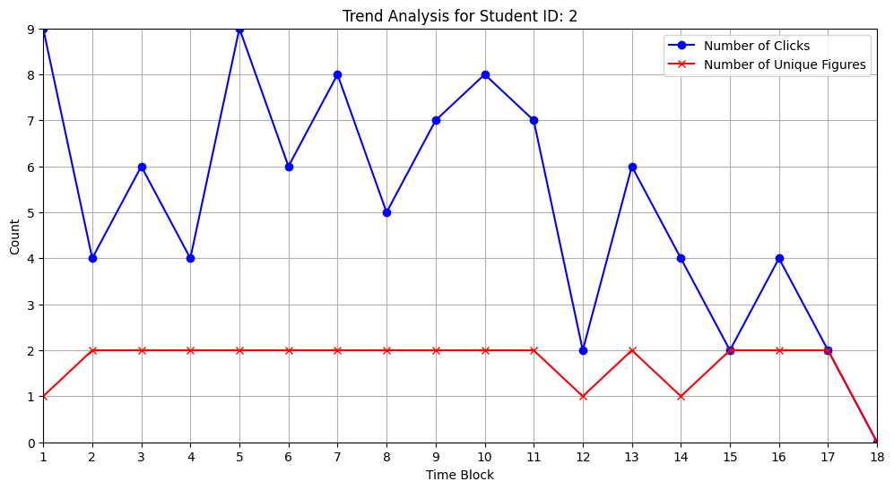

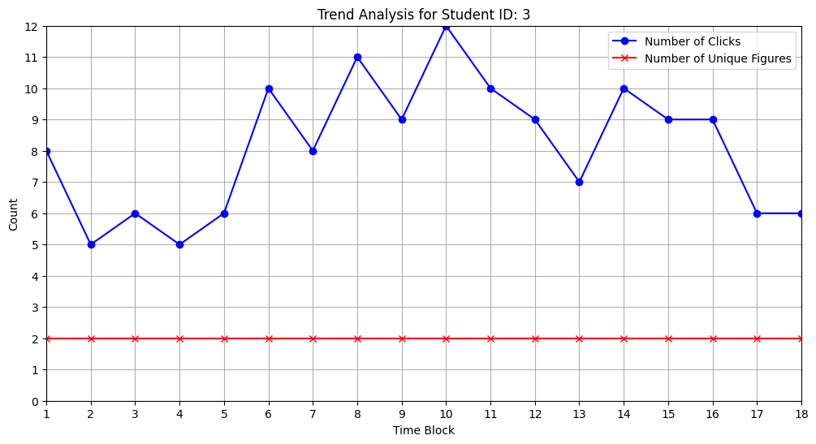

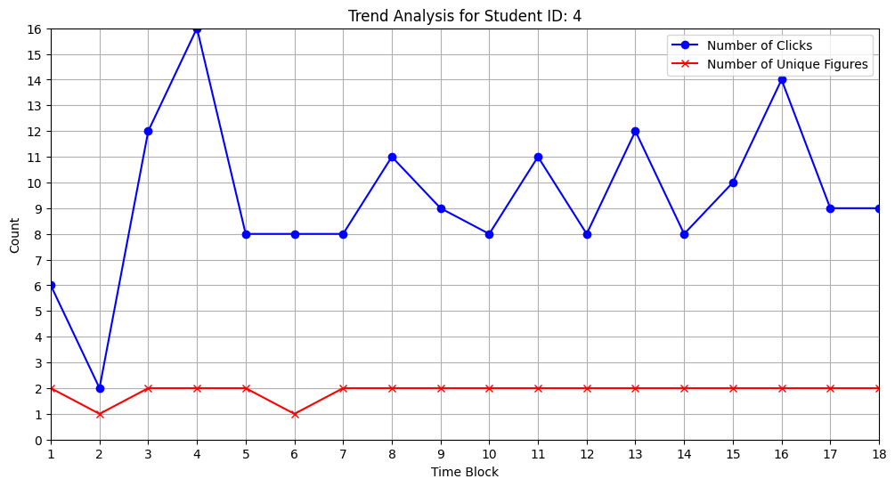

```python
# Trend Analysis: Plotting the trend of clicks and unique figures for each student
for index, row in analysis_df.iterrows():

    if index != 0:
        clicks_per_block = [row[f'Block_{i+1}_Clicks'] for i in range(TOTAL_BLOCKS)]
        unique_figures_per_block = [row[f'Block_{i+1}_Unique_Patterns'] for i in range(TOTAL_BLOCKS)]

        plt.figure(figsize=(12, 6))

        # Plotting clicks
        plt.plot(range(TOTAL_BLOCKS), clicks_per_block, marker='o', color='blue', label='Number of Clicks')

        # Plotting unique figures
        plt.plot(range(TOTAL_BLOCKS), unique_figures_per_block, marker='x', color='red', label='Number of Unique Figures')

        plt.title(f'Trend Analysis for Student ID: {row["Student_ID"]}')
        plt.xlabel('Time Block')
        plt.ylabel('Count')

        # Set x-axis and y-axis to start at 0 and increment in steps of 1
        plt.xticks(range(TOTAL_BLOCKS), range(1, TOTAL_BLOCKS + 1))  # Set x-ticks to start from 1
        plt.xlim(0, TOTAL_BLOCKS - 1)  # Set x-axis to start from 0
        max_count = max(max(clicks_per_block), max(unique_figures_per_block))
        plt.yticks(range(max_count + 1))  # Set y-ticks to increment in steps of 1
        plt.ylim(0, max_count)  # Set y-axis to start from 0

        plt.legend()
        plt.grid(True)
        plt.show()

    # Limit the number of plots for demonstration purposes
    if index == 3:
        break
```

One the first chart however, you could argue that as the test goes on, that the amount of clicks it needs to make a unique figure (as in, possibly better figured out how the test works) goes down, on average.

# Preprocessing

### The elbow method

The elbow method is used to determine the optimal number of clusters (K) for K-Means clustering. It helps strike a balance between cluster quality and complexity by identifying the point where adding more clusters doesn't significantly reduce within-cluster variance (WCSS). The elbow point in the WCSS plot is chosen as the optimal K.

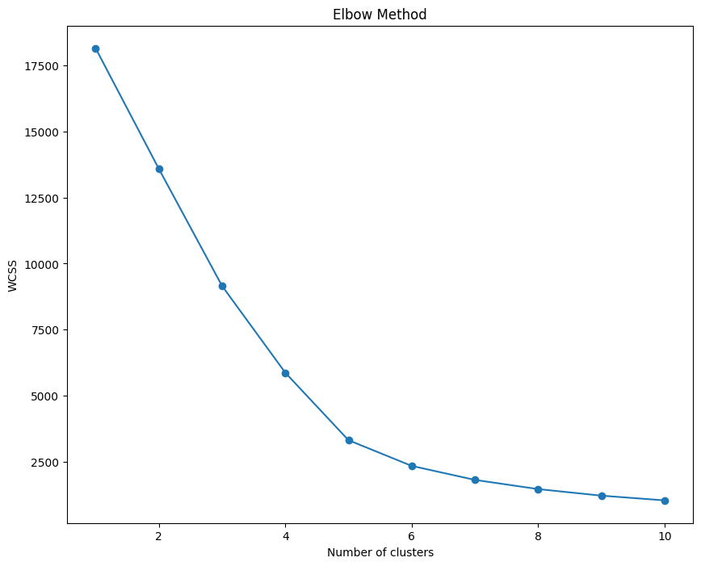

```
      Student_ID  Cluster
0              1        3
1              2        3
2              3        0
3              4        0
4              5        0
...          ...      ...
4532       10052        3
4533       10054        3
4534       10055        3
4535       10056        3
4536       10058        0

[4537 rows x 2 columns]
```

```python
from sklearn.cluster import KMeans
from sklearn.preprocessing import StandardScaler

# Corrected function to convert time in 'min sec' format to seconds
def convert_time_to_seconds(t):
    if isinstance(t, str):  # Check if the input is a string
        if 'min' in t:
            minutes, seconds = t.replace(' sec', '').split(' min ')
            return float(minutes) * 60 + float(seconds)
        else:
            return float(t.replace(' sec', ''))
    else:
        return t  # Return the input if it's not a string

# Applying the corrected function to the DataFrame
analysis_df['Average_Time_Between_Clicks'] = analysis_df['Average_Time_Between_Clicks'].apply(lambda x: convert_time_to_seconds(str(x)))
analysis_df['Test_Duration'] = analysis_df['Test_Duration'].apply(lambda x: convert_time_to_seconds(str(x)))

features = ['Total_Clicks', 'Total_Unique_Figures', 'Average_Time_Between_Clicks', 'Test_Duration']
X = analysis_df[features]

# Normalize the features
scaler = StandardScaler()
X_scaled = scaler.fit_transform(X)

# Calculate WCSS for a range of k values
wcss = []
for i in range(1, 11):
    kmeans = KMeans(n_clusters=i, init='k-means++', max_iter=300, n_init=10, random_state=42)
    kmeans.fit(X_scaled)
    wcss.append(kmeans.inertia_)

# Plot the elbow graph
plt.figure(figsize=(10, 8))
plt.plot(range(1, 11), wcss, marker='o')
plt.title('Elbow Method')
plt.xlabel('Number of clusters')
plt.ylabel('WCSS')
plt.show()

optimal_clusters = 4  # Based on the elbow plot you

# Run K-Means with the optimal number of clusters
kmeans_optimal = KMeans(n_clusters=optimal_clusters, init='k-means++', max_iter=300, n_init=10, random_state=42)
analysis_df['Cluster'] = kmeans_optimal.fit_predict(X_scaled)

# Output the dataframe with the cluster assignments
print(analysis_df[['Student_ID', 'Cluster']])
```

### PCA

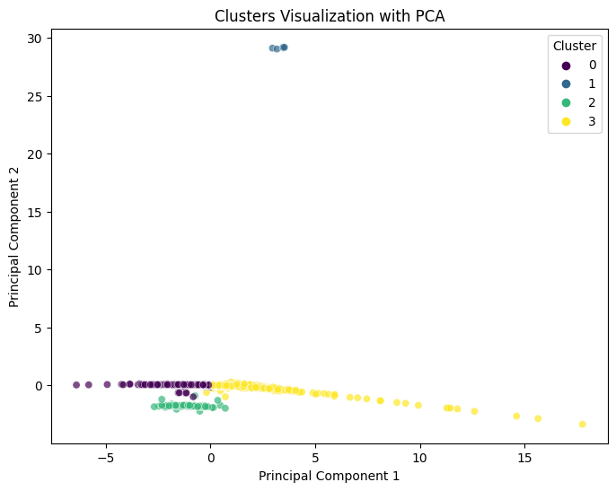

```
                                 PCA1      PCA2
Total_Clicks                -0.875868 -0.017589
Total_Unique_Figures        -0.088978 -0.965003
Average_Time_Between_Clicks  0.866319 -0.148378
Test_Duration               -0.120097 -0.227085
```

```python
from sklearn.decomposition import PCA

# Cluster Characterization
# Compute the mean of each feature within each cluster
cluster_characteristics = analysis_df.groupby('Cluster').mean()


# 3. Further Exploration with PCA
# Normalize the feature space
features = ['Total_Clicks', 'Total_Unique_Figures', 'Average_Time_Between_Clicks', 'Test_Duration']
X = analysis_df[features]
scaler = StandardScaler()
X_scaled = scaler.fit_transform(X)

# PCA to reduce to 2 dimensions for visualization
pca = PCA(n_components=2)
X_pca = pca.fit_transform(X_scaled)

# Adding PCA results into the DataFrame
analysis_df['PCA1'] = X_pca[:, 0]
analysis_df['PCA2'] = X_pca[:, 1]

# Plotting the clusters
plt.figure(figsize=(8, 6))
sns.scatterplot(data=analysis_df, x='PCA1', y='PCA2', hue='Cluster', palette='viridis', alpha=0.7)
plt.title('Clusters Visualization with PCA')
plt.xlabel('Principal Component 1')
plt.ylabel('Principal Component 2')
plt.legend(title='Cluster')
plt.show()

# Displaying the cluster characteristics for further interpretation
cluster_characteristics.reset_index()


# Assuming you have already fitted PCA as 'pca' and 'features' are your original features
loadings = pca.components_.T * np.sqrt(pca.explained_variance_)

# Create a DataFrame of loadings with features and components
loading_matrix = pd.DataFrame(loadings, columns=['PCA1', 'PCA2'], index=features)

print(loading_matrix)
```

Each dot is a student, and each colour is a certain cluster.

Based on the chart, you can see that for the majority the clusters have been divided well, there is not a lot of overlap throughout different clusters grouped together.

### Silhouette

Here you can see for each cluster how they are performing and how similar they are to each other

```python
# First, let's print out the cluster characteristics for interpretation.
cluster_characteristics = analysis_df.groupby('Cluster').mean()

# For in-depth cluster analysis and profiling, we will look at statistical summaries within each cluster.
cluster_summaries = analysis_df.groupby('Cluster').describe()

# Displaying the cluster characteristics for interpretation
print("Cluster Characteristics:")
print(cluster_characteristics)

# Displaying statistical summaries for each cluster
print("\nCluster Summaries:")
print(cluster_summaries)

# Now let's compute the silhouette score to measure the quality of the clusters.
from sklearn.metrics import silhouette_score

# We only compute silhouette score if we have more than 1 cluster
if len(cluster_characteristics) > 1:
    silhouette_avg = silhouette_score(X_scaled, analysis_df['Cluster'])
    print(f"\nSilhouette Score: {silhouette_avg:.2f}")
```

```
Cluster Characteristics:
          Student_ID  Total_Clicks  Total_Unique_Figures  \
Cluster
0        5679.050164    159.909951                   2.0
1        2750.400000     32.000000                   1.0
2        3961.888889    145.513889                   2.0
3        4703.224359     91.243097                   2.0

         Average_Time_Between_Clicks  Test_Duration  Block_1_Clicks  \
Cluster
0                           1.256044   1.716498e+04        8.266859
1                           1.104000   6.145960e+02        8.600000
2                           1.441944   1.694831e+07        8.125000
3                           2.216686   1.588908e+04        6.604043

         Block_1_Unique_Patterns  Block_2_Clicks  Block_2_Unique_Patterns  \
Cluster
0                       1.815378        7.697780                 1.798109
1                       1.000000        2.200000                 0.400000
2                       1.666667        6.916667                 1.666667
3                       1.609467        5.180966                 1.541420

         Block_3_Clicks  ...  Block_15_Clicks  Block_15_Unique_Patterns  \
Cluster                  ...
0              8.013569  ...         8.092516                  1.857319
1              3.200000  ...         0.000000                  0.000000
2              7.611111  ...         7.111111                  1.763889
3              5.292899  ...         4.211045                  1.369329

         Block_16_Clicks  Block_16_Unique_Patterns  Block_17_Clicks  \
Cluster
0               8.020970                  1.852796         7.958059
1               0.000000                  0.000000         0.000000
2               6.958333                  1.750000         7.694444
3               4.277613                  1.373274         4.067061

         Block_17_Unique_Patterns  Block_18_Clicks  Block_18_Unique_Patterns  \
Cluster
0                        1.828536         7.925576                  1.797697
1                        0.000000         0.000000                  0.000000
```

[output cut: 33 more lines]

```
1           5.0  29.120738  0.059664  29.027736  29.102181  29.130900
2          72.0  -1.766594  0.160236  -2.235616  -1.810287  -1.771715
3        2028.0  -0.056485  0.196873  -3.370955  -0.059114  -0.017890


               75%        max
Cluster
0         0.054006   0.129288
1        29.170665  29.172209
2        -1.740667  -0.909376
3         0.003283   0.263065

[4 rows x 344 columns]

Silhouette Score: 0.49
```

The silhouette score is 49%, the higher the score, the more similar the clusters are. 49% in that context is not that great.

The ANOVA (Analysis of Variance) test is used in our project to determine if there are statistically significant differences in the 'Test_Duration' means across the different clusters identified in the FPT (Five Point Test) data. By comparing the average test durations between clusters, we can assess whether the observed differences are likely due to random chance or if they reflect a true variation in test-taking behavior that could be related to underlying factors. such as cognitive abilities, test strategies, or other characteristics captured by the clusters. The F-statistic from the ANOVA test measures the degree of variation between the group means, and the p-value tells us whether this variation is statistically significant

```python
from scipy.stats import f_oneway
# Extracting test durations for each cluster
test_durations = {cluster: analysis_df['Test_Duration'][analysis_df['Cluster'] == cluster] for cluster in analysis_df['Cluster'].unique()}

# Perform ANOVA test
anova_results = f_oneway(*test_durations.values())

# Output the ANOVA test results
anova_results_statistic = anova_results.statistic
anova_results_p_value = anova_results.pvalue

anova_results_statistic, anova_results_p_value
```

```
(54859.15196642816, 0.0)
```

Here we load up the other 2 datasets and merge them together

```python
file_path = 'big5 - big5.csv'
big5_df = pd.read_csv(file_path)

file_path = 'eindtoets - eindtoets.csv'
cito_scores_df = pd.read_csv(file_path)

# Merge 'big5_df' with 'cito_scores_df' using 'idll_vo3lv' as the key
merged_df = big5_df.merge(cito_scores_df, on='idll_vo3lv', how='inner')

# Merge the result with 'analysis_df' using 'Student_ID' as the key
merged_df = analysis_df.merge(merged_df, left_on='Student_ID', right_on='idll_vo3lv', how='inner')

# Drop the duplicate 'idll_vo3lv' column
merged_df.drop(columns=['idll_vo3lv'], inplace=True)

# Display the first few rows of the merged dataset for verification
merged_df.head()
# Displaying the first few rows of the merged dataset for verification
merged_df.head()
```

|  | Student_ID | Total_Clicks | Total_Unique_Figures | Average_Time_Between_Clicks | Test_Duration | Block_1_Clicks | Block_1_Unique_Patterns | Block_2_Clicks | Block_2_Unique_Patterns | Block_3_Clicks | ... | agree | neur | schooljaar | standaardscore | ond_opgaves8000 | ond_percgoed8000 | ond_opgaves8001 | ond_percgoed8001 | ond_opgaves8002 | ond_percgoed8002 |
| --- | --- | --- | --- | --- | --- | --- | --- | --- | --- | --- | --- | --- | --- | --- | --- | --- | --- | --- | --- | --- | --- |
| 0 | 8 | 95 | 2 | 1.90 | 178.96 | 6 | 2 | 6 | 2 | 8 | ... | -0.069872 | 0.652435 | 2016-2017 | 529 | 93 | 68.9 | 42 | 49.4 | 45.0 | 50.0 |
| 1 | 11 | 67 | 2 | 1.60 | 105.35 | 5 | 2 | 4 | 1 | 3 | ... | -1.739933 | -0.086619 | 2016-2017 | 533 | 89 | 65.9 | 57 | 67.1 | 56.0 | 62.2 |
| 2 | 18 | 106 | 2 | 1.81 | 21089193.84 | 7 | 2 | 0 | 0 | 0 | ... | 1.075826 | 1.405262 | 2016-2017 | 534 | 85 | 63.0 | 66 | 77.6 | 33.0 | 36.7 |
| 3 | 30 | 159 | 2 | 1.25 | 19956949.19 | 9 | 2 | 8 | 2 | 9 | ... | -1.281864 | 0.345009 | 2016-2017 | 530 | 84 | 62.2 | 55 | 64.7 | 53.0 | 58.9 |
| 4 | 36 | 186 | 2 | 1.08 | 6579297.79 | 7 | 2 | 3 | 2 | 0 | ... | -0.083606 | -0.504403 | 2016-2017 | 522 | 73 | 54.1 | 38 | 44.7 | 42.0 | 46.7 |

5 rows × 84 columns

We then save it into a new csv for ease of workability

```python
# Define the file path where you want to save the merged dataset
output_file_path = 'merged_datasets.csv'

# Save the merged DataFrame to a CSV file
merged_df.to_csv(output_file_path, index=False)

# Print a message to confirm that the dataset has been saved
print(f"Merged dataset saved to {output_file_path}")
```

```
Merged dataset saved to merged_datasets.csv
```

# Modelling

Here we select the 5 personalit trait scores as the targets for the prediction we will make, and extract the features and target variables from the merged dataset we just created

```python
# Selecting Big 5 Personality Traits Scores as the targets for prediction
targets_big5 = ['neur', 'agree', 'extra', 'cons', 'open']
# Extracting the features and target variables from the merged dataset
features = merged_df.drop(columns=targets_big5)  # All columns except the Big 5 scores
targets = merged_df[targets_big5]  # Only the Big 5 scores

print(merged_df)

# Checking for any missing values in the target variables
missing_values = targets.isnull().sum()

missing_values, features.columns.tolist()
```

```
      Student_ID  Total_Clicks  Total_Unique_Figures  \
0              8            95                     2
1             11            67                     2
2             18           106                     2
3             30           159                     2
4             36           186                     2
...          ...           ...                   ...
1758        9732           155                     2
1759        9733           139                     2
1760        9734           275                     2
1761        9736           160                     2
1762        9737           226                     2

      Average_Time_Between_Clicks  Test_Duration  Block_1_Clicks  \
0                            1.90         178.96               6
```

[output cut: 64 more lines]

```
(neur     19
 agree    20
 extra    19
 cons     19
 open     19
 dtype: int64,
 ['Student_ID',
  'Total_Clicks',
  'Total_Unique_Figures',
  'Average_Time_Between_Clicks',
  'Test_Duration',
  'Block_1_Clicks',
  'Block_1_Unique_Patterns',
  'Block_2_Clicks',
  'Block_2_Unique_Patterns',
  'Block_3_Clicks',
  'Block_3_Unique_Patterns',
  'Block_4_Clicks',
  'Block_4_Unique_Patterns',
  'Block_5_Clicks',
  'Block_5_Unique_Patterns',
  'Block_6_Clicks',
  'Block_6_Unique_Patterns',
  'Block_7_Clicks',
  'Block_7_Unique_Patterns',
  'Block_8_Clicks',
  'Block_8_Unique_Patterns',
  'Block_9_Clicks',
  'Block_9_Unique_Patterns',
  'Block_10_Clicks',
  'Block_10_Unique_Patterns',
  'Block_11_Clicks',
  'Block_11_Unique_Patterns',
  'Block_12_Clicks',
  'Block_12_Unique_Patterns',
  'Block_13_Clicks',
  'Block_13_Unique_Patterns',
  'Block_14_Clicks',
  'Block_14_Unique_Patterns',
  'Block_15_Clicks',
```

[output cut: 30 more lines]

```
  'karak94_vo3lv',
  'karak95_vo3lv',
  'karak96_vo3lv',
  'karak16b_vo3lv',
  'karak97_vo3lv',
  'karak2b_vo3lv',
  'karak98_vo3lv',
  'schooljaar',
  'standaardscore',
  'ond_opgaves8000',
  'ond_percgoed8000',
  'ond_opgaves8001',
  'ond_percgoed8001',
  'ond_opgaves8002',
  'ond_percgoed8002'])
```

Here we check if there are any remaining missing values, and fill them with the mean of each column

```python
print(features.columns)

from sklearn.impute import SimpleImputer
# Creating an imputer object to fill missing values with the mean of each column
imputer = SimpleImputer(missing_values=np.nan, strategy='mean')

# Applying the imputer to the target columns
targets_imputed = imputer.fit_transform(targets)

# Creating a DataFrame for the imputed target variables
targets_imputed_df = pd.DataFrame(targets_imputed, columns=targets_big5)

# Checking for any remaining missing values in the target variables
missing_values_post_imputation = targets_imputed_df.isnull().sum()
```

```
Index(['Student_ID', 'Total_Clicks', 'Total_Unique_Figures',
       'Average_Time_Between_Clicks', 'Test_Duration', 'Block_1_Clicks',
       'Block_1_Unique_Patterns', 'Block_2_Clicks', 'Block_2_Unique_Patterns',
       'Block_3_Clicks', 'Block_3_Unique_Patterns', 'Block_4_Clicks',
       'Block_4_Unique_Patterns', 'Block_5_Clicks', 'Block_5_Unique_Patterns',
       'Block_6_Clicks', 'Block_6_Unique_Patterns', 'Block_7_Clicks',
       'Block_7_Unique_Patterns', 'Block_8_Clicks', 'Block_8_Unique_Patterns',
       'Block_9_Clicks', 'Block_9_Unique_Patterns', 'Block_10_Clicks',
       'Block_10_Unique_Patterns', 'Block_11_Clicks',
       'Block_11_Unique_Patterns', 'Block_12_Clicks',
       'Block_12_Unique_Patterns', 'Block_13_Clicks',
       'Block_13_Unique_Patterns', 'Block_14_Clicks',
       'Block_14_Unique_Patterns', 'Block_15_Clicks',
       'Block_15_Unique_Patterns', 'Block_16_Clicks',
       'Block_16_Unique_Patterns', 'Block_17_Clicks',
       'Block_17_Unique_Patterns', 'Block_18_Clicks',
       'Block_18_Unique_Patterns', 'Cluster', 'PCA1', 'PCA2', 'karak2_vo3lv',
       'karak6_vo3lv', 'karak12_vo3lv', 'karak50_vo3lv', 'karak92_vo3lv',
       'karak87_vo3lv', 'karak8_vo3lv', 'karak88b_vo3lv', 'karak16_vo3lv',
       'karak20_vo3lv', 'karak89_vo3lv', 'karak7_vo3lv', 'karak11b_vo3lv',
       'karak15_vo3lv', 'karak19_vo3lv', 'karak5_vo3lv', 'karak10b_vo3lv',
       'karak53b_vo3lv', 'karak93_vo3lv', 'karak90_vo3lv', 'karak94_vo3lv',
       'karak95_vo3lv', 'karak96_vo3lv', 'karak16b_vo3lv', 'karak97_vo3lv',
       'karak2b_vo3lv', 'karak98_vo3lv', 'schooljaar', 'standaardscore',
       'ond_opgaves8000', 'ond_percgoed8000', 'ond_opgaves8001',
       'ond_percgoed8001', 'ond_opgaves8002', 'ond_percgoed8002'],
      dtype='object')
```

Here we select the features and the target which is the cluster, because we are going to predict the cluster. And then after we scale it for the model. We scale it to make sure no feature has more weight than the other. Because in this context it doesn't.

```python
import pandas as pd
from sklearn.model_selection import train_test_split
from sklearn.ensemble import RandomForestClassifier
from sklearn.preprocessing import StandardScaler
from sklearn.impute import SimpleImputer
from sklearn.metrics import accuracy_score, classification_report, confusion_matrix

# Preprocessing
imputer = SimpleImputer(strategy='mean')
scaler = StandardScaler()

# Selecting features and target
feature_columns = ['open', 'cons', 'extra', 'agree', 'neur', 'standaardscore']
target_column = 'Cluster'

X = merged_df[feature_columns]
y = merged_df[target_column]


X_imputed = imputer.fit_transform(X)
X_scaled = scaler.fit_transform(X_imputed)

# Split the data
X_train, X_test, y_train, y_test = train_test_split(X_scaled, y, test_size=0.2, random_state=42)

# Train the model
classifier = RandomForestClassifier(random_state=42)
classifier.fit(X_train, y_train)

# Predictions and evaluation
y_pred = classifier.predict(X_test)
print("Accuracy:", accuracy_score(y_test, y_pred))
print("Classification Report:\n", classification_report(y_test, y_pred))
print("Confusion Matrix:\n", confusion_matrix(y_test, y_pred))
```

```
Accuracy: 0.5297450424929179
Classification Report:
               precision    recall  f1-score   support

           0       0.60      0.66      0.63       210
           2       0.00      0.00      0.00         4
           3       0.40      0.35      0.38       139

    accuracy                           0.53       353
   macro avg       0.33      0.34      0.33       353
weighted avg       0.51      0.53      0.52       353

Confusion Matrix:
 [[138   0  72]
 [  3   0   1]
 [ 90   0  49]]
```

As you can see in the above printed text, the accuracy of our model is 52%.

# Evaluation

Below we will inference the predictions so we can see what it is predicting. We also use cross validation to avoid oversampling.

```python
from imblearn.over_sampling import SMOTE
from sklearn.model_selection import GridSearchCV, cross_val_score
from sklearn.ensemble import RandomForestClassifier
from sklearn.metrics import classification_report, confusion_matrix
from imblearn.pipeline import Pipeline as ImbPipeline
from sklearn.decomposition import PCA
from collections import Counter
from sklearn.ensemble import RandomForestClassifier, GradientBoostingClassifier

# Handling data imbalance
class_counts = Counter(y_train)
smallest_class_count = min(class_counts.values())
k_neighbors_smote = max(smallest_class_count - 1, 1)
smote = SMOTE(k_neighbors=k_neighbors_smote)

# Hyperparameter tuning setup
param_grid = {
    'classifier__n_estimators': [100, 200],
    'classifier__max_depth': [None, 10, 20]
    # Add other parameters here
}

# Create the pipeline
pipeline = ImbPipeline([
    ('smote', smote),
    ('classifier', RandomForestClassifier(random_state=42))
])

# Grid Search for hyperparameter tuning
grid_search = GridSearchCV(pipeline, param_grid, cv=5, scoring='accuracy')
grid_search.fit(X_train, y_train)

# Best model from grid search
best_model = grid_search.best_estimator_

# Cross-validation
cv_scores = cross_val_score(best_model, X_train, y_train, cv=5, scoring='accuracy')


# Trying Gradient Boosting
gb_model = GradientBoostingClassifier(random_state=42)
gb_model.fit(X_train, y_train)


# Convert X_test to DataFrame if it's not already
if not isinstance(X_test, pd.DataFrame):
    X_test = pd.DataFrame(X_test, columns=feature_columns)

selected_indices = range(15)
X_test_selected = X_test.iloc[selected_indices]
y_test_selected = y_test.iloc[selected_indices]
y_pred_gb_selected = gb_model.predict(X_test_selected)
# Getting predicted probabilities for the selected examples
y_pred_proba_gb_selected = gb_model.predict_proba(X_test_selected)


# Printing the evaluation results for each of the first 15 examples with individual "confidence"
for i, idx in enumerate(selected_indices):
    actual_cluster = y_test_selected.iloc[i]
    predicted_cluster = y_pred_gb_selected[i]
    predicted_probabilities = y_pred_proba_gb_selected[i]
    confidence = max(predicted_probabilities)  # The highest probability as the confidence

    print(f"Example {i+1} - Index: {idx}")
    print(f"Actual Cluster: {actual_cluster}")
    print(f"Predicted Cluster: {predicted_cluster}")
    print(f"Confidence: {confidence:.2f}\n")

# Overall evaluation for the entire test set
y_pred_gb_full = gb_model.predict(X_test)
accuracy_full = accuracy_score(y_test, y_pred_gb_full)

print("Gradient Boosting Classification Report:\n", classification_report(y_test, y_pred_gb_full))
print("Gradient Boosting Confusion Matrix:\n", confusion_matrix(y_test, y_pred_gb_full))
print(f"Overall Test Set Accuracy: {accuracy_full}")
```

[output not shown]

[output cut: 25 more lines]

[output not shown]

```
Example 1 - Index: 0
Actual Cluster: 0
Predicted Cluster: 0
Confidence: 0.88

Example 2 - Index: 1
Actual Cluster: 3
Predicted Cluster: 3
Confidence: 0.63

Example 3 - Index: 2
Actual Cluster: 3
Predicted Cluster: 0
Confidence: 0.77

Example 4 - Index: 3
Actual Cluster: 0
Predicted Cluster: 3
Confidence: 0.76

Example 5 - Index: 4
Actual Cluster: 3
Predicted Cluster: 3
Confidence: 0.50

Example 6 - Index: 5
Actual Cluster: 3
Predicted Cluster: 0
Confidence: 0.53

Example 7 - Index: 6
Actual Cluster: 3
Predicted Cluster: 0
Confidence: 0.72

Example 8 - Index: 7
Actual Cluster: 0
Predicted Cluster: 3
Confidence: 0.51

```

[output cut: 36 more lines]

```
               precision    recall  f1-score   support

           0       0.64      0.69      0.66       210
           2       0.00      0.00      0.00         4
           3       0.48      0.44      0.46       139

    accuracy                           0.58       353
   macro avg       0.37      0.37      0.37       353
weighted avg       0.57      0.58      0.58       353

Gradient Boosting Confusion Matrix:
 [[144   2  64]
 [  2   0   2]
 [ 78   0  61]]
Overall Test Set Accuracy: 0.5807365439093485
```